# Proctor Data Analysis Assessment

Author:Yueran Zhang(yz4188@cumc.columbia.edu)

2023-04-14

### R package

Here are the packages we would use in this exercise.

```r
library(dplyr)
library(moments)
library(repr)
library(ggplot2)
library(onehot)
library(gridExtra)
library(boot)
```

### Session 1 - Data process

###### This section, we focus on data import, merge and manipulation.

##### STEPS:

1. In this part, we would first import two data files into R Markdown by using function *“read.csv”*. One is for child level data, another is for additional community-level characteristics.
2. In order to have a better understanding of these related variables, we merge these two variables by using function *“full_join”*, which provide us a very quick tool to join the union variables,keeps data that appear in either dataframes.
3. With the final step in this section, we will add a new variable called **serpositivity**, this variable measures whether whether the child was seropositive to either the SEA antigen(variable:sea_pos) or the Sm25 antigen(variable:sm25_pos).
- If any of these two variable represents is coded as 1(shown positive status), we will record the new variable as positive; otherwise, if both variables are coded as 0(shown as negative), the new variable will show negative.
4. In order to make sure all the above steps are correct, we will check the new joined dataset.

```r
#---------------------------
# Import data
#---------------------------

# Child level data
schisto.data <- read.csv("./data/mbita_schisto.csv") %>%
  janitor::clean_names()

# Additional community-level characteristics
spatial.data <- read.csv("./data/mbita_spatial.csv") %>%
  janitor::clean_names()

#---------------------------
# Joining Dataframe
#---------------------------

joined.df <- full_join(schisto.data,spatial.data,
                       by = "vid") %>%

#---------------------------
# Add a new variable
#---------------------------
 mutate(serpositivity =
          ifelse(
            sea_pos == 1 | sm25_pos == 1, "Positive", "Negative") )
```

```r
#---------------------------
#Check for safety
#---------------------------
head(joined.df)
##   year vid arm pid     agey    sex   sea sm25 sm_epg sea_pos sm25_pos kk_pos
## 1 2012   1 CWT   1 1.812457   male  3136   -2     12       1        0      1
## 2 2012   1 CWT   2 2.168378 female 25605 1344     12       1        1      1
## 3 2012   1 CWT   3 2.954141 female 28549  520      0       1        1      0
## 4 2012   1 CWT   4 2.633812 female    87   -4     36       0        0      1
## 5 2012   1 CWT   5 2.540726   male 26537    1     24       1        0      1
## 6 2012   1 CWT   6 3.301848   male 27389    1    132       1        0      1
##   elev   tmin     prec dist_victoria serpositivity
## 1 1189 160.75 82.66667      568.3382      Positive
## 2 1189 160.75 82.66667      568.3382      Positive
## 3 1189 160.75 82.66667      568.3382      Positive
## 4 1189 160.75 82.66667      568.3382      Negative
## 5 1189 160.75 82.66667      568.3382      Positive
## 6 1189 160.75 82.66667      568.3382      Positive
dim(joined.df)
## [1] 3663   17
```

### Section2 - Descpritive of Data

###### This section, we want to do some exploratory data analysis.

```r
#---------------------------
#Summary for the variables' category
#---------------------------
# Number of numeric variables
cat(paste("Number of Numeric Variables: ", sum(sapply(joined.new, is.numeric))))
```

```
## Number of Numeric Variables:  8
```

```r
# Number of categorical variables
cat(paste("\nNumber of Categorical Variables: ", sum(sapply(joined.new, is.factor))))
```

```
##
## Number of Categorical Variables:  8
```

```r
#---------------------------
#Data Summary
#---------------------------
joined.new %>%
skimr::skim()%>%
knitr::knit_print()
```

Data summary

| Name | Piped data |
| --- | --- |
| Number of rows | 3663 |
| Number of columns | 16 |
| _______________________ |  |
| Column type frequency: |  |
| factor | 8 |
| numeric | 8 |
| ________________________ |  |
| Group variables | None |

**Variable type: factor**

| skim_variable | n_missing | complete_rate | ordered | n_unique | top_counts |
| --- | --- | --- | --- | --- | --- |
| year | 0 | 1.00 | FALSE | 3 | 201: 1356, 201: 1187, 201: 1120 |
| arm | 0 | 1.00 | FALSE | 2 | SBT: 1837, CWT: 1826 |
| pid | 0 | 1.00 | FALSE | 3663 | 1: 1, 2: 1, 3: 1, 4: 1 |
| sex | 0 | 1.00 | FALSE | 2 | fem: 1904, mal: 1759 |
| sea_pos | 0 | 1.00 | FALSE | 2 | 0: 1914, 1: 1749 |
| sm25_pos | 0 | 1.00 | FALSE | 2 | 0: 3040, 1: 623 |
| kk_pos | 237 | 0.94 | FALSE | 2 | 0: 2557, 1: 869 |
| serpositivity | 0 | 1.00 | FALSE | 2 | Pos: 1864, Neg: 1799 |

**Variable type: numeric**

| skim_variable | n_missing | complete_rate | mean | sd | p0 | p25 | p50 | p75 | p100 | hist |
| --- | --- | --- | --- | --- | --- | --- | --- | --- | --- | --- |
| agey | 0 | 1.00 | 3.38 | 1.21 | 0.21 | 2.43 | 3.50 | 4.44 | 5.55 | ▂▅▆▇▆ |
| sea | 0 | 1.00 | 11981.74 | 13518.81 | 4.00 | 101.00 | 387.00 | 27337.00 | 32685.00 | ▇▁▁▂▅ |
| sm25 | 0 | 1.00 | 129.26 | 805.77 | -12.00 | 1.15 | 6.00 | 19.00 | 18816.00 | ▇▁▁▁▁ |
| sm_epg | 237 | 0.94 | 42.01 | 187.99 | 0.00 | 0.00 | 0.00 | 12.00 | 5004.00 | ▇▁▁▁▁ |
| elev | 0 | 1.00 | 1169.52 | 34.77 | 1137.00 | 1151.00 | 1158.00 | 1178.00 | 1338.00 | ▇▂▁▁▁ |
| tmin | 0 | 1.00 | 158.64 | 2.37 | 148.92 | 157.42 | 158.83 | 160.75 | 161.42 | ▁▁▂▅▇ |
| prec | 0 | 1.00 | 88.48 | 6.00 | 81.17 | 83.42 | 84.92 | 94.50 | 101.42 | ▇▁▂▅▁ |
| dist_victoria | 0 | 1.00 | 1011.26 | 1015.05 | 32.28 | 234.21 | 712.82 | 1598.12 | 4718.11 | ▇▃▁▁▁ |

From the above summary table,

- For categorical variables, expect variable `kk_pos` has 237 rows of missing data, other variables are in good condition with no missing value.
- For numerical variables,`sm_epg` ,which is the numeric results corresponding to the `kk_pos`variable, has 237 rows of missing data, there is no other variable with missing data.

```r
#---------------------------
#Count missing values by year
#---------------------------
missing.dat <- joined.new %>%
  filter_all(any_vars(is.na(.)))

missing.dat %>%
  count(year) %>%
  knitr::kable(digits = 1)
```

| year | n |
| --- | --- |
| 2012 | 48 |
| 2013 | 15 |
| 2014 | 174 |

- We see the missing data that are sorted by year. The first year missing data from using stool-based measures of infection is 48, and it is noticeable that the final year 2014 had the most number of missing data(n=174).

```r
#---------------------------
#Delete the missing value
#---------------------------

# For Numeric Missing Values - Replace NA with the mean
joined.new$sm_epg[is.na(joined.new$sm_epg)] <- mean(joined.new$sm_epg,na.rm =TRUE)

# Replace NA in categorical variables for empty_means_without

empty_means_without <- c("year", "arm", "pid", "sex", "sea_pos", "sm25_pos",  "serpositivity")
empty_means_NA <- c("kk_pos")

replace_empty_with_without <- function(feature) {
    levels(feature) <- c(levels(feature), "Without")
    feature[is.na(feature)] <- "Without"
    return(feature)
}

for (feature in empty_means_without) {
    joined.new[,feature] <- replace_empty_with_without(joined.new[,feature])
}

joined.new <- na.omit(joined.new)


str(joined.new)
```

[output not shown]

```r
#---------------------------
# Numeric variable characteristic
#---------------------------
num_vars <- sapply(joined.new, is.numeric)
dat_stats <- data.frame(Feature = colnames(joined.new[num_vars]))

options(scipen=10000)
dat_stats['Mean'] <- sapply(joined.new[num_vars], mean)
dat_stats['SD'] <- sapply(joined.new[num_vars], sd)
dat_stats['Skewness'] <- sapply(joined.new[num_vars], skewness)
dat_stats['Kurtosis'] <- sapply(joined.new[num_vars], kurtosis)
dat_stats %>%
  knitr::kable(digits = 3)
```

| Feature | Mean | SD | Skewness | Kurtosis |
| --- | --- | --- | --- | --- |
| agey | 3.416 | 1.205 | -0.338 | 2.049 |
| sea | 12237.317 | 13545.873 | 0.329 | 1.221 |
| sm25 | 129.321 | 767.648 | 12.559 | 204.458 |
| sm_epg | 42.011 | 187.994 | 10.909 | 193.750 |
| elev | 1169.576 | 34.556 | 2.740 | 12.184 |
| tmin | 158.634 | 2.353 | -1.468 | 6.365 |
| prec | 88.504 | 6.002 | 0.359 | 1.523 |
| dist_victoria | 1010.787 | 1012.210 | 1.521 | 4.999 |

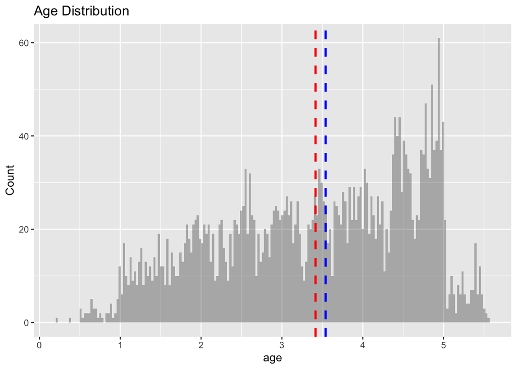

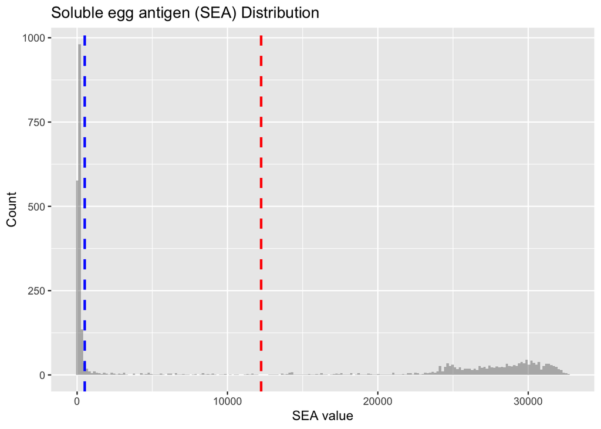

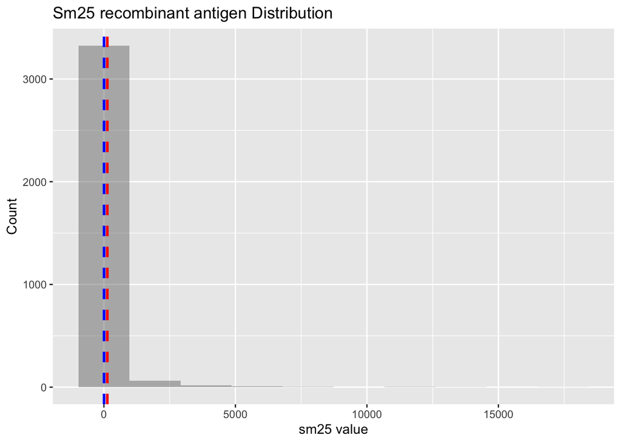

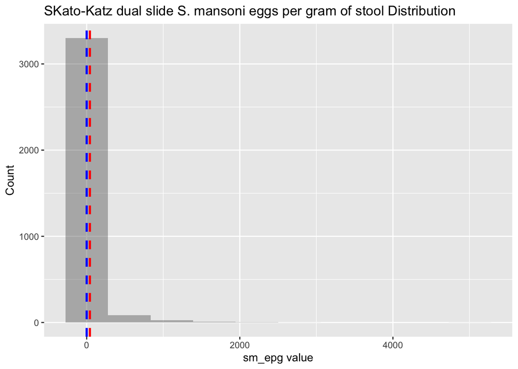

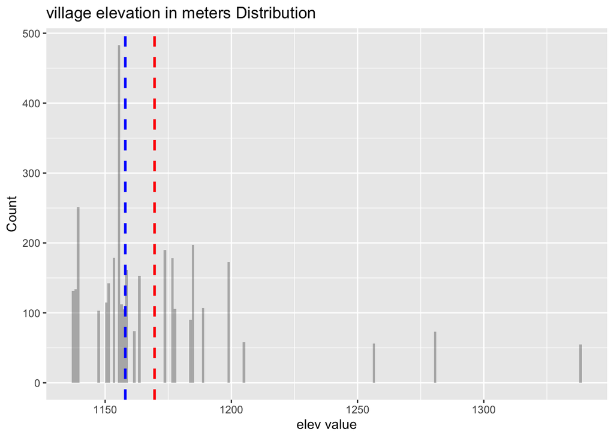

[figure not shown]

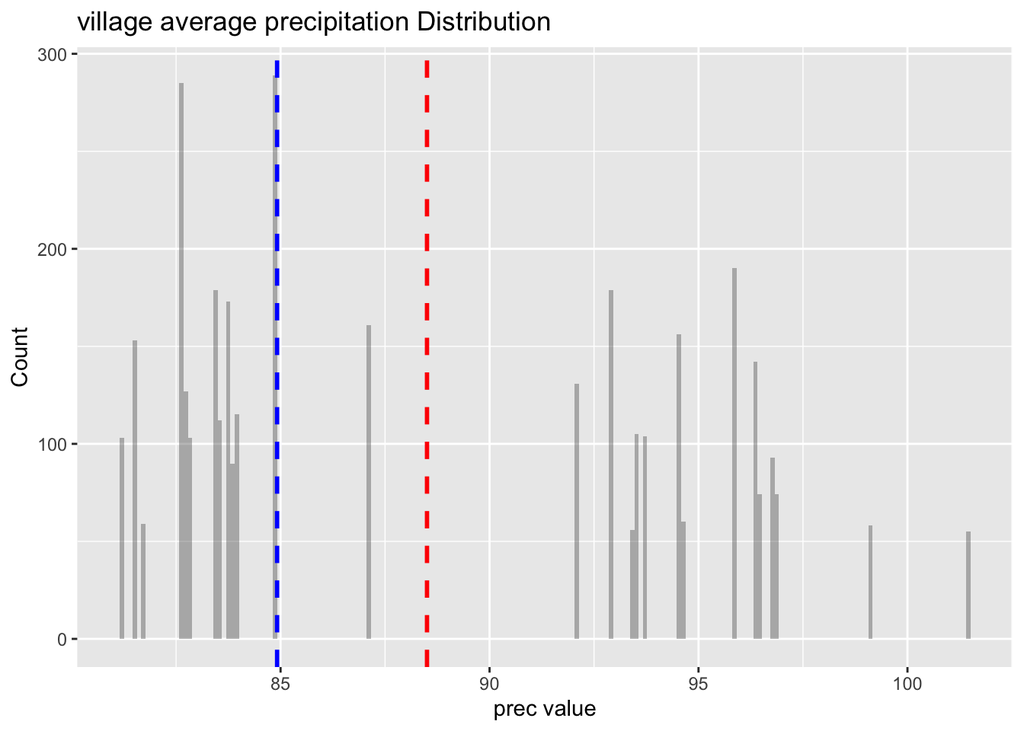

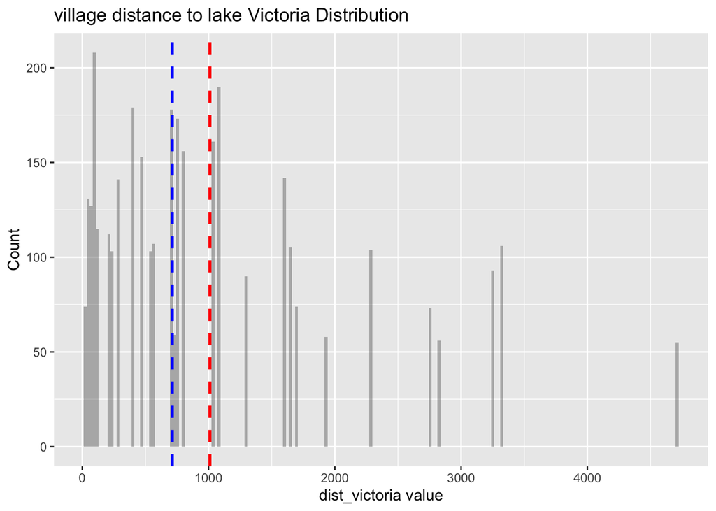

### Section3 - Summarize baseline characteristics

###### This section, we will create a table that summarizes individual-level and cluster-level characteristics by randomized group.

```r
#---------------------------
# Summary for baseline characteristics
#---------------------------

# create a function to compute the p-value for continuous or categorical variables.
pvalue <- function(x, ...) {
    y <- unlist(x)
    g <- factor(rep(1:length(x), times=sapply(x, length)))
    if (is.numeric(y)) {
        p <- t.test(y ~ g)$p.value
    } else {
        p <- chisq.test(table(y, g))$p.value
    }
    c("", sub("<", "&lt;", format.pval(p, digits=3, eps=0.001)))
}

#Table for variable characteristic
table1::table1(~ factor(sex) + agey + sea + sm25 + sm_epg +factor(sea_pos)
                 +factor(sm25_pos) +factor(kk_pos) +factor(serpositivity)
               + elev + tmin + prec + dist_victoria| arm,
               data = baseline.dat,overall=F, extra.col=list(`P-value`=pvalue), caption = "Table1. Baseline characteristics by randomized group",)
```

Table1. Baseline characteristics by randomized group

|  | CWT (N=518) | SBT (N=554) | P-value |
| --- | --- | --- | --- |
| factor(sex) |  |  |  |
| female | 265 (51.2%) | 291 (52.5%) | 0.699 |
| male | 253 (48.8%) | 263 (47.5%) |  |
| agey |  |  |  |
| Mean (SD) | 3.55 (1.23) | 3.48 (1.23) | 0.328 |
| Median [Min, Max] | 3.78 [0.684, 5.51] | 3.68 [0.372, 5.49] |  |
| sea |  |  |  |
| Mean (SD) | 10700 (13000) | 13800 (13600) | <0.001 |
| Median [Min, Max] | 244 [24.0, 32600] | 8820 [4.00, 32700] |  |
| sm25 |  |  |  |
| Mean (SD) | 118 (770) | 93.8 (466) | 0.533 |
| Median [Min, Max] | 4.00 [-5.00, 12100] | 5.00 [-7.00, 5860] |  |
| sm_epg |  |  |  |
| Mean (SD) | 47.6 (183) | 84.3 (337) | 0.0257 |
| Median [Min, Max] | 0 [0, 1930] | 0 [0, 5000] |  |
| factor(sea_pos) |  |  |  |
| Negative | 293 (56.6%) | 243 (43.9%) | <0.001 |
| Positive | 225 (43.4%) | 311 (56.1%) |  |
| factor(sm25_pos) |  |  |  |
| Negative | 451 (87.1%) | 471 (85.0%) | 0.38 |
| Positive | 67 (12.9%) | 83 (15.0%) |  |
| factor(kk_pos) |  |  |  |
| Negative | 394 (76.1%) | 381 (68.8%) | 0.00942 |
| Positive | 124 (23.9%) | 173 (31.2%) |  |
| factor(serpositivity) |  |  |  |
| Negative | 283 (54.6%) | 232 (41.9%) | <0.001 |
| Positive | 235 (45.4%) | 322 (58.1%) |  |
| elev |  |  |  |
| Mean (SD) | 1170 (35.8) | 1170 (25.6) | 0.599 |
| Median [Min, Max] | 1160 [1140, 1340] | 1160 [1140, 1280] |  |
| tmin |  |  |  |
| Mean (SD) | 158 (2.56) | 159 (1.78) | <0.001 |
| Median [Min, Max] | 158 [149, 161] | 159 [153, 161] |  |
| prec |  |  |  |
| Mean (SD) | 89.9 (6.32) | 87.7 (5.29) | <0.001 |
| Median [Min, Max] | 90.3 [81.2, 101] | 84.8 [81.5, 96.5] |  |
| dist_victoria |  |  |  |
| Mean (SD) | 1120 (1020) | 930 (958) | 0.0014 |
| Median [Min, Max] | 1050 [32.3, 4720] | 713 [48.1, 3310] |  |

Reflection:

- In the study, planners thoroughly shuffled and randomly split up study subjects into two groups. Also, if we want to improve the balance between two groups,using a placebo, which allowed the study to be double-blinded (neither subjects nor researchers knew who got which treatment). Randomization minimizes noncomparability due to confounding and protects the study from any biases that may be introduced by the researchers into the assignment process. Blinding preserves the benefits of randomization by preventing biased reporting of symptoms or assessment of outcomes.